# Human Or Not Human - Tratamento

Rafael Dadão

2024-05-20

# Carregando bibliotecas

```r
library(dplyr)
library(randomForest)
library(ggplot2)
library(reshape2)
```

# Verificando o dataframe

```r
head(starwars)
```

```
## # A tibble: 6 × 14
##   name      height  mass hair_color skin_color eye_color birth_year sex   gender
##   <chr>      <int> <dbl> <chr>      <chr>      <chr>          <dbl> <chr> <chr>
## 1 Luke Sky…    172    77 blond      fair       blue            19   male  mascu…
## 2 C-3PO        167    75 <NA>       gold       yellow         112   none  mascu…
## 3 R2-D2         96    32 <NA>       white, bl… red             33   none  mascu…
## 4 Darth Va…    202   136 none       white      yellow          41.9 male  mascu…
## 5 Leia Org…    150    49 brown      light      brown           19   fema… femin…
## 6 Owen Lars    178   120 brown, gr… light      blue            52   male  mascu…
## # ℹ 5 more variables: homeworld <chr>, species <chr>, films <list>,
## #   vehicles <list>, starships <list>
```

```r
# Selecionando colunas de interesse
columns <- c("height","mass","hair_color","skin_color","eye_color","species")

# Atribuindo o conjunto de dados selecionados a um objeto
df <- starwars %>% select(all_of(columns))
```

# Consultando valores missing

```r
colSums(is.na(df))
```

```
##     height       mass hair_color skin_color  eye_color    species
##          6         28          5          0          0          4
```

Vimos que peso tem muito valores NA, vamos tentar explorar melhor o atributo para entendê-lo

## Histograma do peso

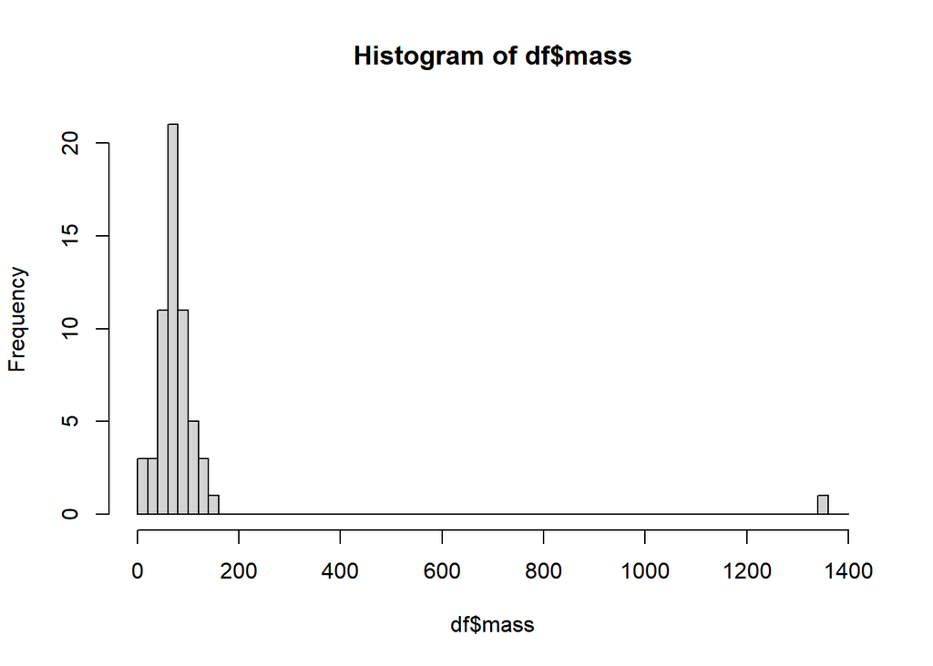

```r
hist(df$mass, breaks = seq(0, 1400, by = 20))
```

```r
# vemos que há oulier de peso
```

## Scatter plot de peso e altura

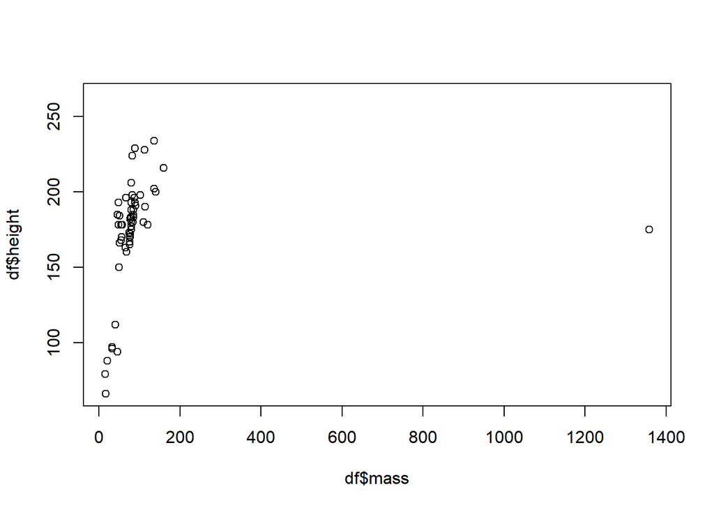

```r
plot(df$mass, df$height)
```

```r
# quanto maior a altura, maior o peso, para a maioria dos casos
```

## Vamos identificar o outlier

```r
subset(df, df$mass > 1000)
```

```
## # A tibble: 1 × 6
##   height  mass hair_color skin_color       eye_color species
##    <int> <dbl> <chr>      <chr>            <chr>     <chr>
## 1    175  1358 <NA>       green-tan, brown orange    Hutt
```

```r
# outlier é um Hutt
```

## Vamos olhar o conjunto de atributos para os casos com peso NA

```r
print(subset(df, is.na(df$mass)), n = 28)
```

```
## # A tibble: 28 × 6
##    height  mass hair_color   skin_color  eye_color species
##     <int> <dbl> <chr>        <chr>       <chr>     <chr>
##  1    180    NA auburn, grey fair        blue      Human
##  2    150    NA auburn       fair        blue      Human
##  3     NA    NA brown        fair        brown     Human
##  4    170    NA blond        fair        blue      Human
##  5    206    NA none         green       orange    Gungan
##  6    183    NA brown        fair        blue      Human
##  7    137    NA black        blue, grey  yellow    Toydarian
##  8    183    NA black        dark        brown     Human
##  9    163    NA black        fair        brown     Human
## 10    180    NA none         pale        pink      Twi'lek
## 11    122    NA none         white, blue black     Xexto
## 12    171    NA black        brown       brown     Zabrak
```

[output cut: 16 more lines]

## Quantas espécies únicas temos?

```r
df %>% summarise(n_distinct(species))
```

```
## # A tibble: 1 × 1
##   `n_distinct(species)`
##                   <int>
## 1                    38
```

Vamos fazer uma média de peso por espécie, pois acredito que o peso vá ser muito diferente entre elas

```r
mean_mass <- df %>% group_by(species) %>% summarise(media_peso = mean(mass, na.rm = TRUE))
print(mean_mass, n = 38)
```

```
## # A tibble: 38 × 2
##    species        media_peso
##    <chr>               <dbl>
##  1 Aleena               15
##  2 Besalisk            102
##  3 Cerean               82
##  4 Chagrian            NaN
##  5 Clawdite             55
##  6 Droid                69.8
##  7 Dug                  40
##  8 Ewok                 20
##  9 Geonosian            80
## 10 Gungan               74
## 11 Human                81.3
## 12 Hutt               1358
```

[output cut: 26 more lines]

Vamos preencher os valores ausentes com a média do peso da espécie

```r
df_miss <- subset(df, is.na(mass))

df_miss <- left_join(df_miss, mean_mass, by = "species") %>%
  select(-c('mass')) %>% rename(mass = media_peso)

df_tratado <- rbind(subset(df, !is.na(df$mass)), df_miss)
```

Pronto, resolvemos o problema do missing data do peso

## Vamos tratar a altura da mesma forma

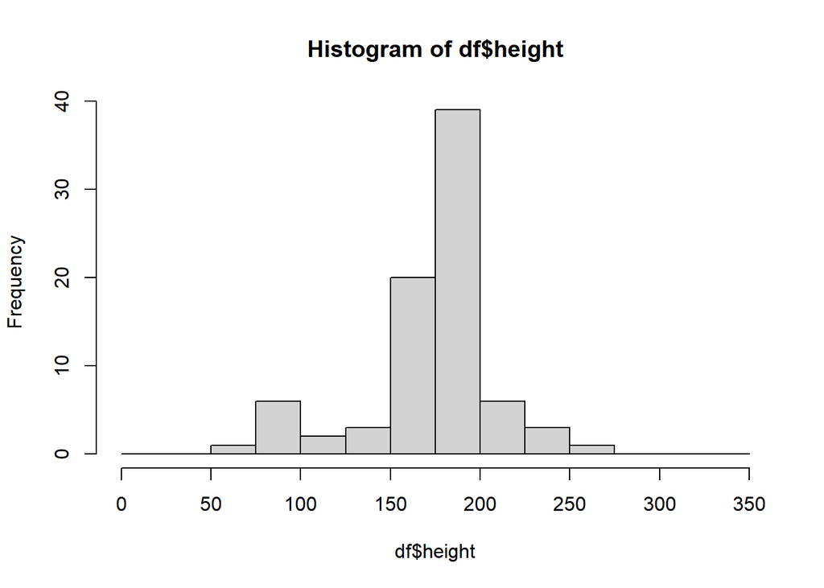

```r
hist(df$height, breaks = seq(0, 350, by = 25))
```

```r
mean_height <- df %>% group_by(species) %>% summarise(media_altura = mean(height, na.rm = TRUE))
print(mean_height, n = 38)
```

```
## # A tibble: 38 × 2
##    species        media_altura
##    <chr>                 <dbl>
##  1 Aleena                  79
##  2 Besalisk               198
##  3 Cerean                 198
##  4 Chagrian               196
##  5 Clawdite               168
##  6 Droid                  131.
##  7 Dug                    112
##  8 Ewok                    88
##  9 Geonosian              183
## 10 Gungan                 209.
## 11 Human                  178
## 12 Hutt                   175
```

[output cut: 26 more lines]

```r
df_miss <- subset(df, is.na(height))

df_miss <- left_join(df_miss, mean_height, by = "species") %>%
  select(-c('height')) %>% rename(height = media_altura)

df_tratado <- rbind(subset(df_tratado, !is.na(df_tratado$height)), df_miss)
```

## Os NA do hair_color vamos transformar em none

```r
print(subset(df, is.na(df$hair_color)), n = 5)
```

```
## # A tibble: 5 × 6
##   height  mass hair_color skin_color       eye_color species
##    <int> <dbl> <chr>      <chr>            <chr>     <chr>
## 1    167    75 <NA>       gold             yellow    Droid
## 2     96    32 <NA>       white, blue      red       Droid
## 3     97    32 <NA>       white, red       red       Droid
## 4    173    74 <NA>       green            black     Rodian
## 5    175  1358 <NA>       green-tan, brown orange    Hutt
```

```r
# nenhuma dessas espécies possui cabelo mesmo
df_tratado <- df_tratado %>% mutate(hair_color = ifelse(is.na(hair_color), "none", hair_color))
```

## Os valores que não conseguimos preencher de peso e os missing da coluna target (species) serão excluídos

```r
df_tratado <- df_tratado[complete.cases(df_tratado),]
# Excluindo linhas com valores missing
```

# Transformando character em fator

```r
columns_chr = c('hair_color','skin_color','eye_color','species')

df_tratado <- df_tratado %>%
  mutate_at(vars(columns_chr), as.factor)
```

# Criando variável target identificando se é humano ou alien

```r
df_tratado$specie_human <- ifelse(df_tratado$species == "Human", 1, 0)
df_tratado$specie_human <- as.factor(df_tratado$specie_human)
```

# Excluindo species

```r
df_tratado <- df_tratado %>% select(-'species')

str(df_tratado)
```

```
## tibble [71 × 6] (S3: tbl_df/tbl/data.frame)
##  $ height      : num [1:71] 172 167 96 202 150 178 165 97 183 182 ...
##  $ mass        : num [1:71] 77 75 32 136 49 120 75 32 84 77 ...
##  $ hair_color  : Factor w/ 11 levels "auburn","auburn, grey",..: 5 10 10 10 7 8 7 10 4 3 ...
##  $ skin_color  : Factor w/ 30 levels "blue","blue, grey",..: 7 9 28 27 17 17 17 29 17 7 ...
##  $ eye_color   : Factor w/ 12 levels "black","blue",..: 2 12 9 12 4 2 2 9 4 3 ...
##  $ specie_human: Factor w/ 2 levels "0","1": 2 1 1 2 2 2 2 1 2 2 ...
```